# Investment Strategy Project

2020-10-01T21:28:43-05:00

Our study group has built financial models to test the effectiveness of Merger Arbitrage.

The rationale of this strategy is that the target company’s shares trade for less than the merger’s proposed per-share value—a spread that compensates the investor for the risk of the transaction not closing, as well as for the time value of money until closing. This spread does not come riskless, because there is always a chance that the merger won’t take place, leading to decline in target’s price and subsequently losses for hedge funds. The idea of the risk arbitrage strategy is to immediately after announcement of merger or acquisition, the investor should buy the stock of the target company and short sell the stock of the acquiring company.

# Data Collection

## Benchmark data

First, we need to load the necessary data: Risk free rates, financial indicies, and list of M&A deals to investigate.

Risk-free Rates

```r
tbill <- vroom("https://fred.stlouisfed.org/graph/fredgraph.csv?bgcolor=%23e1e9f0&chart_type=line&drp=0&fo=open%20sans&graph_bgcolor=%23ffffff&height=450&mode=fred&recession_bars=on&txtcolor=%23444444&ts=12&tts=12&width=1168&nt=0&thu=0&trc=0&show_legend=yes&show_axis_titles=yes&show_tooltip=yes&id=DTB3&scale=left&cosd=2009-08-01&coed=2020-10-09&line_color=%234572a7&link_values=false&line_style=solid&mark_type=none&mw=3&lw=2&ost=-99999&oet=99999&mma=0&fml=a&fq=Daily&fam=avg&fgst=lin&fgsnd=2020-02-01&line_index=1&transformation=lin&vintage_date=2020-10-14&revision_date=2020-10-14&nd=1954-01-04") %>%
  mutate(DTB3 = DTB3/100) %>%
  rename("date" = "DATE",
         "T_bill" = "DTB3") %>%
  mutate(T_bill_d = (1 + T_bill)^(1/252)-1,
         date = as.Date(date,"%Y-%m-%d"))
```

Indices

```r
benchmark <-
  data.frame(index = c("MNA", "^RUA", "^FTSE","^FTAS", "^IXIC","NYA", "^DJI", "^GSPC"),
             description = c("IQ Merger Arbitrage ETF", "Russell_3000", "FTSE 100", "FTSE All Share","NASDAQ_Composite", "NYSE Composite", "Dow Jones Industrial Average", "SP_500")) %>%
  tq_get(get  = "stock.prices",
         from = "2009-01-01",
         to   = "2020-08-31") %>%
  select(index, description, date, close) %>%
  group_by(index) %>%
  mutate(index_return = close/lag(close) - 1)
```

## Merger Data

Merger Deals

In order to create our data set, we used the acquired deal data from Bloomberg and downloaded the respective companies’ opening stock prices from Yahoo Finance. Here, a significant portion of the data was omitted as many of the M&A targets are delisted, and thus no longer tracked on Yahoo Finance. Recognising that companies which have been successfully are more likely to become delisted, we acknowledged that our data set for targets may be significantly biased – the information for completed deals is more inclusive and representative than that of failed takeover deals.

```r
stocks2 <- read_excel("MA_vF.xlsx", sheet = "Sheet1") %>%
  select(acquirer, target, DealStatus, announce_date, close_date) %>%
  mutate(DealStatus = case_when(
    DealStatus == "Completed" ~ DealStatus,
    TRUE ~ "Failed"),
    DealID = paste(acquirer,target))
```

## Get Stock Data and build Dataframes

### Acquirer Data

```r
acquirer_raw <- stocks2 %>%
  select(acquirer) %>%
  tq_get(get  = "stock.prices",
         from = "2009-01-01",
         to   = "2020-08-31") %>%
  select(date, acquirer, open, close)
```

### Target Data

```r
target_raw <- stocks2 %>%
  select(target) %>%
  tq_get(get  = "stock.prices",
         from = "2009-01-01",
         to   = "2020-08-31") %>%
  select(date, target, open, close)
```

### Reformat

```r
# Reformat acquirer data
stock_data_acquirer <- acquirer_raw %>%
  group_by(acquirer) %>%
  mutate(close_acquirer = sprintf("%.2f", open, na.rm = TRUE)) %>%
  select(acquirer, date, close_acquirer)
```

```r
# Reformat target data
stock_data_target <- target_raw %>%
  group_by(target) %>%
  mutate(close_target = sprintf("%.2f", open, na.rm = TRUE)) %>%
  select(target, date, close_target)
```

# Trade from 1 day past announcement date

```r
acq_tar <- stocks2 %>%

  #Add acquirer data
  left_join(stock_data_acquirer, by = c("acquirer")) %>%
  distinct(DealID, date, .keep_all = T) %>%
  mutate(announce_date = as.Date(announce_date,"%Y-%m-%d", tz = "America/New_York"),
         close_date = as.Date(close_date,"%Y-%m-%d", tz = "America/New_York"),
         standard_date = date - announce_date,
         standard_date2 = lead(standard_date, n = 2L)) %>%
  group_by(DealID) %>%
  filter(standard_date >= -2,
         date <= close_date) %>%
  mutate(period = row_number(),
         period = period + as.numeric(time_length( min(standard_date), "days")) -2 ) %>%

  # Add target data
  left_join(stock_data_target, by = c("target", "date")) %>%
  drop_na(close_target) %>%

  # Add Acquirer Returns
  group_by(DealID) %>%
  mutate(close_acquirer = as.numeric(close_acquirer, na.rm = TRUE),
    ret_acq = ifelse(period < 0, NA, ifelse(period > 0, close_acquirer/lag(close_acquirer) - 1, 0))) %>%

  # Add target Returns
  group_by(DealID) %>%
  mutate(close_target = as.numeric(close_target, na.rm = TRUE),
    ret_tar = ifelse(period < 0, NA, ifelse(period > 0, close_target/lag(close_target) - 1, 0))) %>%

  # Add combined returns

  mutate(ret_combined =  ifelse(is.na(ret_tar),NA, ifelse(is.na(ret_acq),NA, ret_tar - ret_acq))) %>%
  # mutate(ret_combined = ifelse(DealStatus == "Completed", ret_tar - ret_acq,  ret_acq - ret_tar)) %>% # If predict deal succeeds vs predict deal fails, assuming 100% predictive capabilities - CAN CHANGE
  # Get rid of non-sense returns
  filter(!is.infinite(ret_combined))
```

## Daily Return and Acquirer - Target Spread

We found that in the early days after an announcement the target’s stocks tends to outperform the acquirer and achieves a positive return. The acquirer’s stock on the other hand often suffers from negative returns. As can be seen in the chart below this spread quickly vanishes and is predominantly kept alive by some sporadic high returns of targets in our data set.

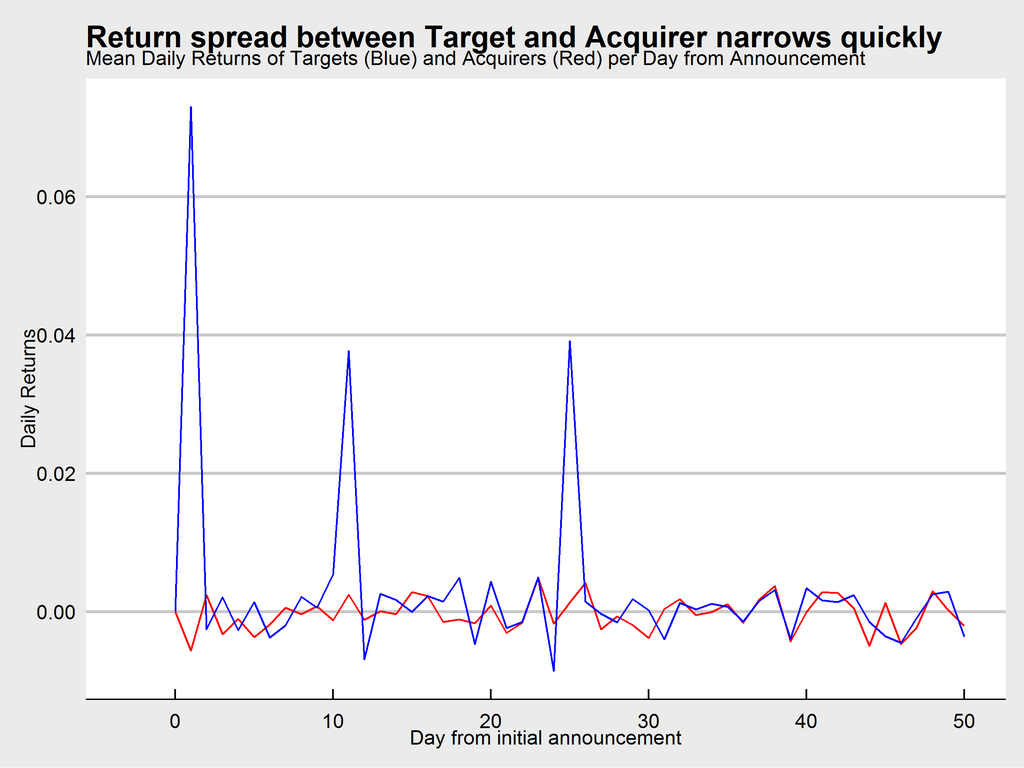

```r
graph1 <- acq_tar %>%
  group_by(period) %>%
  # Summarise means per period whilst removing all NAs. Bad data quality forces us to do this
  summarise(mean_acq = mean(ret_acq, na.rm = TRUE),
            mean_tar = mean(ret_tar, na.rm = TRUE),
            mean_strat = mean(ret_combined, na.rm = TRUE)) %>%
  filter(period <= 50) %>%
  ggplot() +
  theme_bw() +
  geom_line(aes(x = period, y = (mean_acq)), colour = "red") + # Acquirer return
  geom_line(aes(x = period, y = (mean_tar)), colour = "blue") + # Target return

  labs(title = "Return spread between Target and Acquirer narrows quickly",
       subtitle = "Mean Daily Returns of Targets (Blue) and Acquirers (Red) per Day from Announcement",
       y = "Daily Returns",
       x = "Day from initial announcement") +
  theme_economist_white()

ggsave("Return Spread Target an Acquirer.png",
       plot = last_plot(),
       scale = 1,
       width = 20,
       height = 15,
       units = "cm",
       dpi = 300,
       limitsize = TRUE)

knitr::include_graphics(here::here("content/projects/project3", "Return Spread Target an Acquirer.png"), error = FALSE)
```

As our to-be-tested strategy longs the target’s and shorts the acquirer’s stocks we should be expecting predominantly positive returns in the early days after an announcement and moves towards zero over time. The next chart shows exactly this expected result.

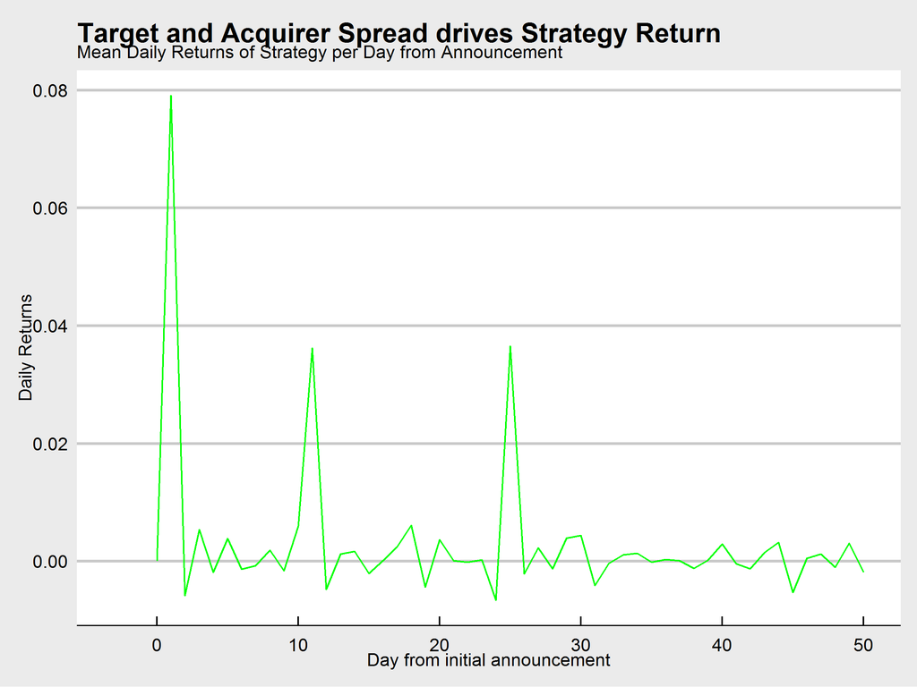

```r
graph2 <- acq_tar %>%
  group_by(period) %>%
  # Summarise means per period whilst removing all NAs. Bad data quality forces us to do this
  summarise(mean_acq = mean(ret_acq, na.rm = TRUE),
            mean_tar = mean(ret_tar, na.rm = TRUE),
            mean_strat = mean(ret_combined, na.rm = TRUE)) %>%
  filter(period <= 50) %>%
  ggplot() +
  theme_bw() +
  geom_line(aes(x = period, y = (mean_strat)), colour = "green") + # Portfolio
  labs(title = "Target and Acquirer Spread drives Strategy Return",
       subtitle = "Mean Daily Returns of Strategy per Day from Announcement",
       y = "Daily Returns",
       x = "Day from initial announcement") +
  theme_economist_white()

ggsave("Strategy Return from Spread.png",
       plot = last_plot(),
       scale = 1,
       width = 20,
       height = 15,
       units = "cm",
       dpi = 300,
       limitsize = TRUE)

knitr::include_graphics(here::here("content/projects/project3", "Strategy Return from Spread.png"), error = FALSE)
```

## Cumulative Return

### Acquirer

```r
# Cumulative return for acquirer
initial_acq <- acq_tar %>%
  filter(period == 0) %>%
  rename(initial_acq = close_acquirer) %>%
  select(acquirer, target, initial_acq) %>%
  distinct()

cum_acq <- left_join(acq_tar, initial_acq, by = c("acquirer", "target")) %>%
  mutate(cum_ret_acq = ifelse(period > -1, close_acquirer/initial_acq - 1, NA)) %>%
  group_by(period) %>%
  summarise(mean_cum_ret_acq = mean(cum_ret_acq, na.rm =TRUE)) %>%
  filter(period <= 50)
```

### Target

```r
# Cumulative return for target
initial_tar <- acq_tar %>%
  filter(period == 0) %>%
  rename(initial_tar = close_target) %>%
  select(acquirer, target, initial_tar) %>%
  distinct()

cum_tar <- left_join(acq_tar, initial_tar, by = c("acquirer", "target")) %>%
  mutate(cum_ret_tar = ifelse(period > -1, close_target/initial_tar - 1, NA)) %>%
  group_by(period) %>%
  summarise(mean_cum_ret_tar = mean(cum_ret_tar, na.rm =TRUE)) %>%
  filter(period <= 50)
```

### Cumulative Return Spread

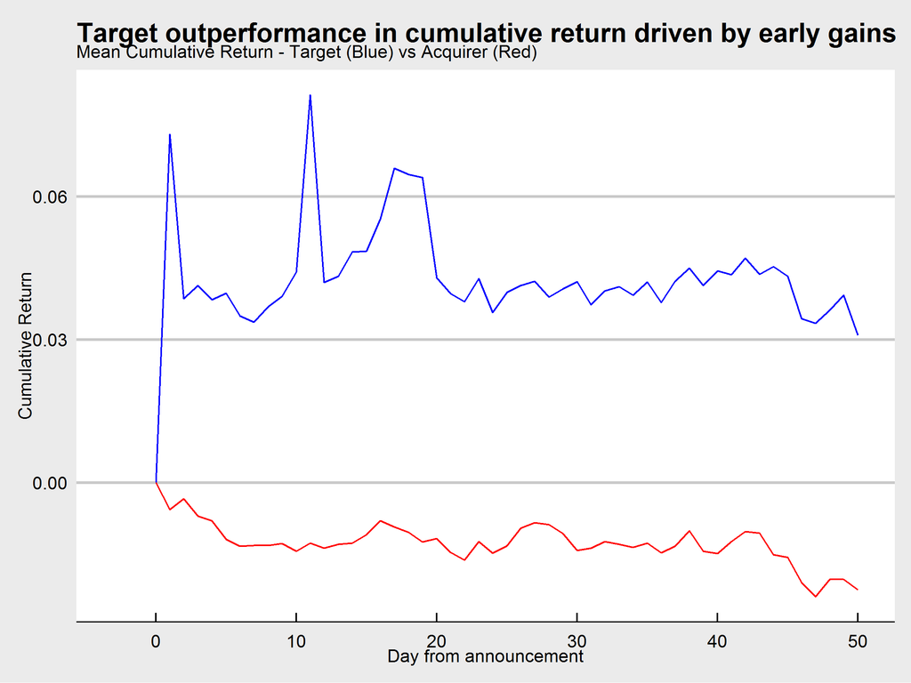

```r
# Combine all
cum_all <- left_join(cum_acq, cum_tar, by = "period") %>%
  filter(period <= 50)


graph3 <- ggplot(cum_all) +

  geom_line(aes(x = period, y = mean_cum_ret_tar), colour = "blue") +
  geom_line(aes(x = period, y = mean_cum_ret_acq), colour = "red") +
  theme_bw() +
  labs(subtitle = "Mean Cumulative Return - Target (Blue) vs Acquirer (Red)",
       title = "Target outperformance in cumulative return driven by early gains",
       y = "Cumulative Return",
       x = "Day from announcement") +
  theme_economist_white()

ggsave("Cumulative Returns Target and Acquirer.png",
       plot = last_plot(),
       scale = 1,
       width = 20,
       height = 15,
       units = "cm",
       dpi = 300,
       limitsize = TRUE)

knitr::include_graphics(here::here("content/projects/project3", "Cumulative Returns Target and Acquirer.png"), error = FALSE)
```

As we can see the majority of the spread is produced within the first five days from announcement, with the spread essentially staying flat from day 25 onwards.

Clearly there seems to be a trend in our data of targets outperforming the acquiring companies.

## Correlation between return and deal completion

### Acquirer

```r
end_acq <- acq_tar %>%
  mutate(diff = close_date - date) %>%
  filter(diff == 0) %>%
  rename(end_acq = close_acquirer) %>%
  select(acquirer, period, target, end_acq, DealStatus) %>%
  distinct()


deal_ret_acq <- left_join(end_acq, initial_acq, by = c("acquirer", "target")) %>%
  distinct() %>%
  mutate(annualised_ret = (end_acq/initial_acq)^(252/period) - 1) %>%
  group_by(DealStatus) %>%
  summarise(mean_annualised_acq_ret = mean(annualised_ret, na.rm = TRUE))

deal_ret_acq
```

| DealStatus | mean_annualised_acq_ret |
| --- | --- |
| Completed | 0.0545 |
| Failed | -0.407 |

### Target

```r
end_tar <- acq_tar %>%
  mutate(diff = close_date - date) %>%
  filter(diff == 0) %>%
  rename(end_tar = close_target) %>%
  select(acquirer, period, target, end_tar, DealStatus) %>%
  distinct()


deal_ret_tar <- left_join(end_tar, initial_tar, by = c("acquirer", "target")) %>%
  filter(!is.na(end_tar),
         DealID.x != "T STRP") %>%
  mutate(annualised_ret = (end_tar/initial_tar)^(252/period) - 1) %>%
  group_by(DealStatus) %>%
  summarise(mean_annualised_tar_ret = sprintf("%.2f",mean(annualised_ret, na.rm = TRUE)))

deal_ret_tar
```

| DealStatus | mean_annualised_tar_ret |
| --- | --- |
| Completed | 0.49 |
| Failed | -0.17 |

*Huge failed deal target return driven by T - STRP deal, where STRP’s stock increased by 150% in 20 days. As this entirely skewed the mean return to earning almost 30,000% a year, it has been removed.*

We can see that stock price of acquirers and targets share the same trend: on average, their stocks always perform significantly better if an M&A deal materialises, and depreciate otherwise. In addition, the target’s stock also strictly performs better than the acquirer in both situations.

## Returns of strategy over timeline

### S&P 500 when there is no deal

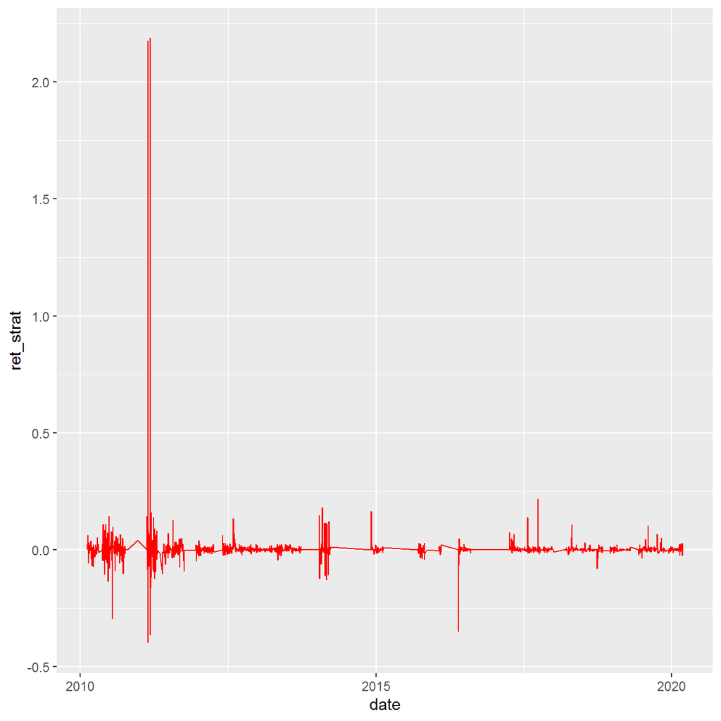

```r
acq_tar2 <- acq_tar %>%
  filter(period <= 50) %>%
  group_by(date) %>%
  summarise(ret_strat = mean(ret_combined)) %>%
  filter(!is.na(ret_strat))




SP_initial <- benchmark %>%
  filter(description == "SP_500") %>%
  filter(date >= "2015-01-01") %>%
  arrange(date) %>%
  head(n = 1) %>%
  rename(initial_index = close) %>%
  select(- date, - index_return)

  ggplot(acq_tar2) +
  geom_line(aes(x = date, y = ret_strat), colour = "red")
```

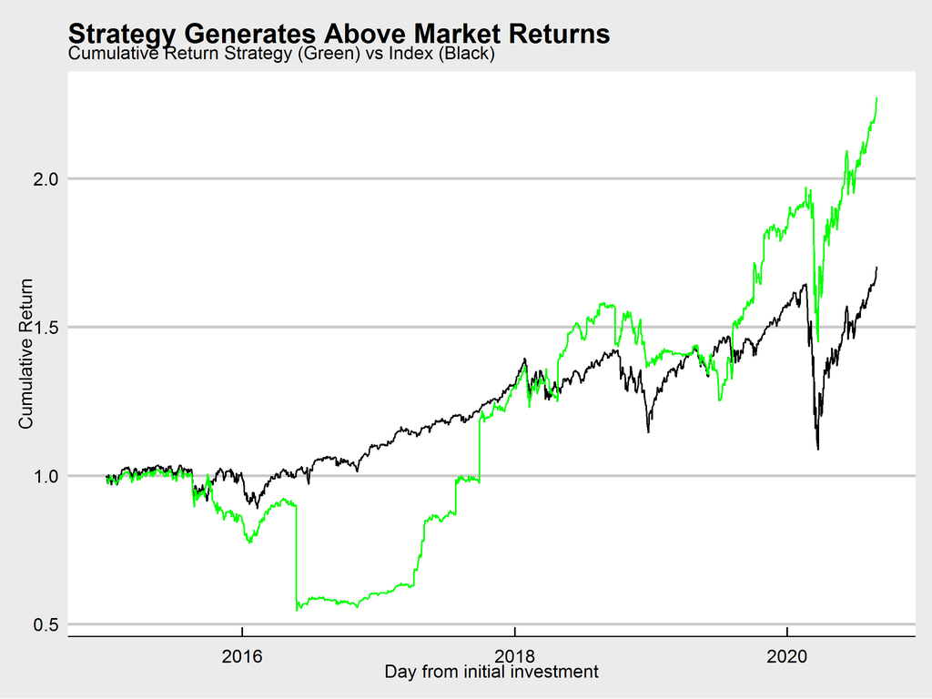

```r
graph4 <- benchmark %>%
  filter(description == "SP_500") %>%
  arrange(date) %>%
  left_join(SP_initial, by = c("description", "index")) %>%
  left_join(acq_tar2, by = "date") %>%
  select(date, close, initial_index, ret_strat) %>%
  mutate(index_ret = close/lag(close) - 1,
         cum_index_ret = close/initial_index,
         ret_strat_adjusted = ifelse(is.na(ret_strat), index_ret, ret_strat)) %>%
  filter(date >= "2015-01-01") %>%
  mutate(retplus1 = ret_strat_adjusted + 1,
    cum_ret_strat = cumprod(retplus1)) %>%
  ggplot() +
  geom_line(aes(x = date, y = cum_index_ret), colour = "black") +
  geom_line(aes(x = date, y = cum_ret_strat), colour = "green") +
  labs(subtitle = "Cumulative Return Strategy (Green) vs Index (Black)",
       title = "Strategy Generates Above Market Returns",
       y = "Cumulative Return",
       x = "Day from initial investment") +
  theme_economist_white()

ggsave("Cumulative Return Strategy vs Index.png",
       plot = last_plot(),
       scale = 1,
       width = 20,
       height = 15,
       units = "cm",
       dpi = 300,
       limitsize = TRUE)

knitr::include_graphics(here::here("content/projects/project3", "Cumulative Return Strategy vs Index.png"), error = FALSE)
```

### Risk free if no deal

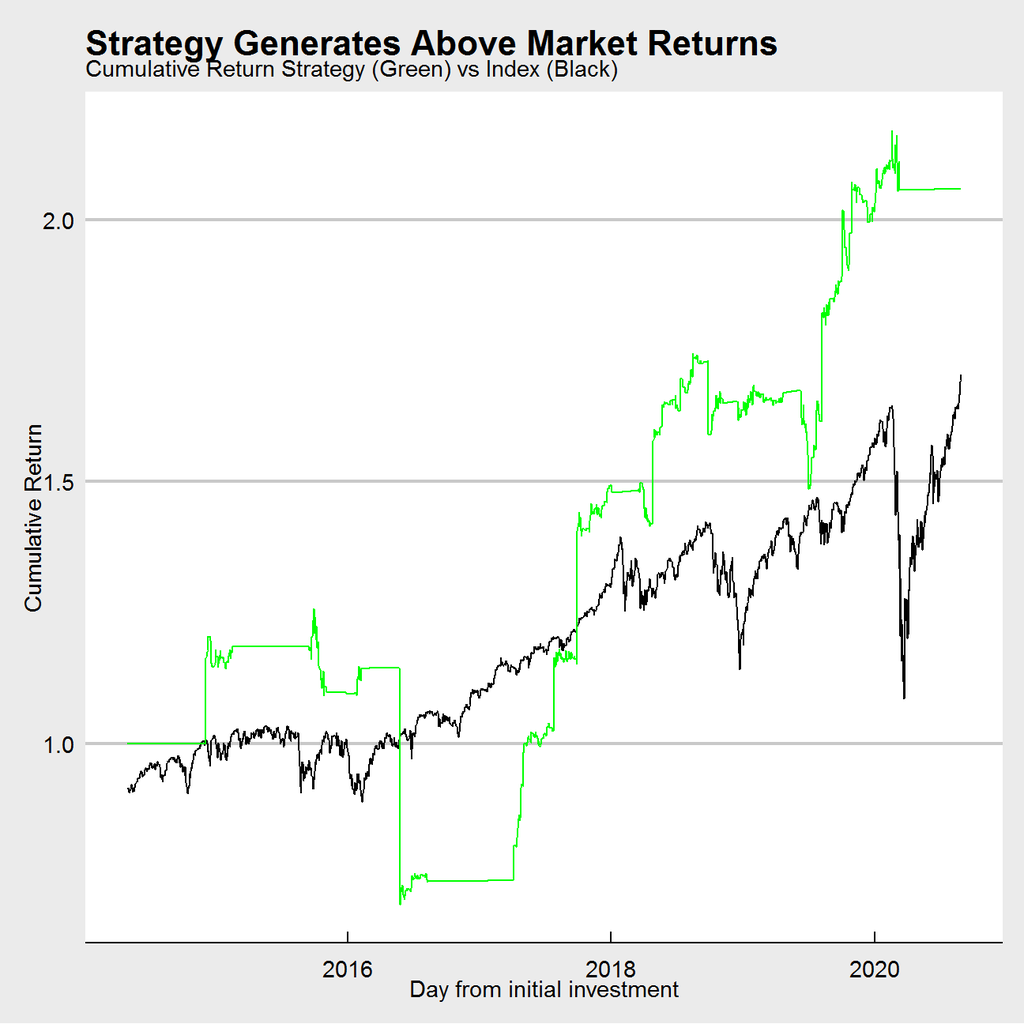

```r
benchmark %>%
  filter(description == "SP_500") %>%
  arrange(date) %>%
  left_join(SP_initial, by = c("description", "index")) %>%
  left_join(acq_tar2, by = "date") %>%
  left_join(tbill, by = "date") %>%
  select(date, close, initial_index, ret_strat, T_bill_d) %>%
  mutate(index_ret = close/lag(close) - 1,
         cum_index_ret = close/initial_index,
         ret_strat_adjusted = ifelse(is.na(ret_strat), T_bill_d, ret_strat)) %>%
  filter(date >= "2014-05-01") %>%
  mutate(retplus1 = ret_strat_adjusted + 1,
    cum_ret_strat = cumprod(retplus1)) %>%
  ggplot() +
  geom_line(aes(x = date, y = cum_index_ret), colour = "black") +
  geom_line(aes(x = date, y = cum_ret_strat), colour = "green") +
  labs(subtitle = "Cumulative Return Strategy (Green) vs Index (Black)",
       title = "Strategy Generates Above Market Returns",
       y = "Cumulative Return",
       x = "Day from initial investment") +
  theme_economist_white()
```

We can take away the following findings from the 2 plots above:

1. On average the target-acquirer spread is positive and transacting on it yields positive results. This return, on average, beats the market return (based on S&P 500).
2. While we performed better than the market than average, our volatility has also been significantly higher. As portrayed in the graph above, there are multiple occurrences of steep losses. Not all announcement will result in price increases for the target, nor the acquirer. An offer at a steep discount might result in the target’s stock price to crash. Our theoretical strategy as per the economic rationale could better hedge this risk, whilst also limiting the upside.

## CAPM

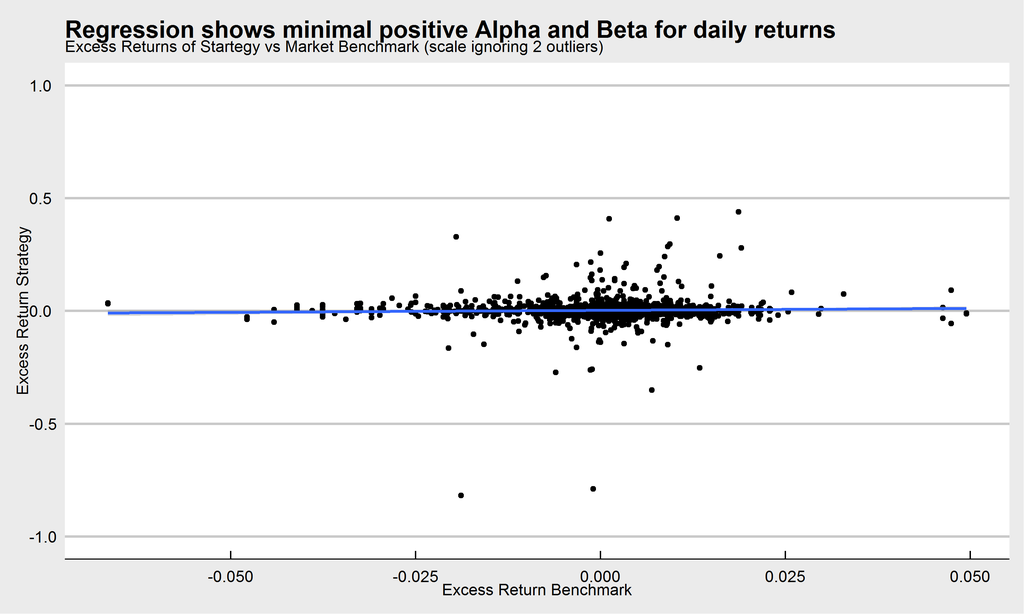

```r
benchmarkSP <- benchmark %>%
  filter(description == "SP_500") %>%
  pivot_wider(values_from = index_return, names_from = description) %>%
  select(date, SP_500)


CAPM <- acq_tar %>%
  filter(period <= 20) %>%
  left_join(tbill, by = "date") %>%
  left_join(benchmarkSP, by = "date") %>%
  filter(!is.na(ret_combined)) %>%
  mutate(Rm_Rf = SP_500 - T_bill_d,
         Rs_Rf = ret_combined - T_bill_d) %>%  # CAN MUTATE RET_Strat = S&P/TBill if return = NA, then use that to replace ret_combined here
  drop_na(Rm_Rf, Rs_Rf) %>%
  filter(!is.infinite(Rs_Rf))

graph5 <- ggplot(CAPM, aes(x = Rm_Rf, y = Rs_Rf, na.rm = TRUE)) +
  geom_point() +
  geom_smooth(method = lm)  +
  ylim(-1,1) +
  labs(subtitle = "Excess Returns of Startegy vs Market Benchmark (scale ignoring 2 outliers)",
       title = "Regression shows minimal positive Alpha and Beta for daily returns",
       y = "Excess Return Strategy",
       x = "Excess Return Benchmark") +
  theme_economist_white()

ggsave("Excess Returns of Startegy vs Market Benchmark.png",
       plot = last_plot(),
       scale = 1,
       width = 25,
       height = 15,
       units = "cm",
       dpi = 300,
       limitsize = TRUE)

knitr::include_graphics(here::here("content/projects/project3", "Excess Returns of Startegy vs Market Benchmark.png"), error = FALSE)
```

```r
CAPM_regression <- lm(Rs_Rf ~ Rm_Rf, data = CAPM, na.rm =TRUE)

CAPM_regression
```

```
##
## Call:
## lm(formula = Rs_Rf ~ Rm_Rf, data = CAPM, na.rm = TRUE)
##
## Coefficients:
## (Intercept)        Rm_Rf
##    0.005882     0.000211
```

```r
huxreg(CAPM_regression,
       statistics = c('#observations' = 'nobs',
                      'R squared' = 'r.squared',
                      'Adj. R Squared' = 'adj.r.squared',
                      'Residual SE' = 'sigma'),
       bold_signif = 0.05,
       stars = NULL
)
```

|  | (1) |
| --- | --- |
| (Intercept) | 0.006 |
|  | (0.003) |
| Rm_Rf | 0.000 |
|  | (0.311) |
| #observations | 2216 |
| R squared | 0.000 |
| Adj. R Squared | -0.000 |
| Residual SE | 0.139 |

```r
msummary(CAPM_regression)
```

```
##             Estimate Std. Error t value Pr(>|t|)
## (Intercept) 0.005882   0.002946       2    0.046 *
## Rm_Rf       0.000211   0.311222       0    0.999
##
## Residual standard error: 0.139 on 2214 degrees of freedom
## Multiple R-squared:  2.07e-10,   Adjusted R-squared:  -0.000452
## F-statistic: 4.58e-07 on 1 and 2214 DF,  p-value: 0.999
```

Looking at the plot of excess returns below, we can clearly see that the strategy seems to be mostly unrelated to the market whilst achieving slightly positive returns.

Our slope β_i not being statistically different from zero for our strategy is intuitive: for every deal we long and short one stock – hence if the trends of their movements are similar, every market related movement should be cancelled out. That being said, we still find a statistically significant alpha that is positive. On average our strategy, assuming perfect foresight, returns 0.58% per trading day, unrelated to the market. However, while it is statistically greater than zero, the value 0.58% per day seems irrationally high, so we suspect the actual value should lie between 0 and the estimated alpha.

We initially wanted to calculate the Treynor Ratio and the Information Ratio. However, as our beta is statistically indifferent from zero, and even the alpha is just barely considered statistically significant (at 95% confidence level), we believe that such ratios, if calculated, would be neither sensible, nor representative.